# Fantasy Premier League

## Navankur Verma - navankurverma@gmail.com

## 8th March 2020

### Contents:

- Motivation
- Pull My FPL Data
  - Storing Data Locally
- Pull General FPL Data
  - Cleaning Data
  - Storing Data Locally
- Pull and Store Historical Data of Players
- Insights from Data
- Visualizing the data
  - How good were my FPL selection?
  - My Points Vs Average Gameweek points
  - Most Suitable Player to Buy Currently

### Motivation

Each year approx 7 million users sign up and create their fantasy football team. Making it most widely used platform for its recreational aspect and now due to its popularity it has turned into a business. I have been using it myself for last 4 years with my friends and colleagues.  
Alongwith fantasy data, it also has stats of each player and team in English Premier League. I will use the data collectively to determine insightful facts of FPL, compare my team to know how well I performed in each gameweek and what transfers should I make to make my team better.

Python Libraries used:

```python
import requests
import json
import pandas as pd
import numpy as np
import matplotlib
import matplotlib.pyplot as plt
import seaborn as sns
import cufflinks as cf
import plotly.express as px
%matplotlib inline
```

### Pull My FPL Data

Move to top

Creating a function to fetch details for given fpl team_id and gameweek number:

```python
def fetch_myteam_gw(teamID, gw):
    url = 'https://fantasy.premierleague.com/api/entry/{}/event/{}/picks/'.format(teamID,gw)
    team = requests.get(url)
    return team.json()
```

My FPL team id is 1025373, which is embedded in url link of "View Gameweek history" on my https://fantasy.premierleague.com/my-team page:

[figure not shown]

```python
myteamID = 1025373
```

```python
mysquads = []
mypoints = []
for x in range(1,39):
    data = fetch_myteam_gw(myteamID,x)
    if "picks"  in data:
        for i in range(0,15):
            data['picks'][i]['gw'] = x ## adding a field for GameWeek number
            mysquads.append(data['picks'][i])
    if "entry_history" in data:
        data['entry_history']['chip'] = "None"
        if data['active_chip'] != None:
            if data['active_chip'] == 'freehit':
                data['entry_history']['chip'] = 'freehit'
            if data['active_chip'] == '3xc':
                data['entry_history']['chip'] = '3xc'
            if data['active_chip'] == 'bboost':
                data['entry_history']['chip'] = 'bboost'
        mypoints.append(data['entry_history'])
mysquads = pd.DataFrame(mysquads)
mypoints = pd.DataFrame(mypoints)
```

```python
mypoints.rename(columns = {'event': 'gw'}, inplace = True)
mysquads.head()
```

|  | element | position | multiplier | is_captain | is_vice_captain | gw |
| --- | --- | --- | --- | --- | --- | --- |
| 0 | 148 | 1 | 1 | False | False | 1 |
| 1 | 182 | 2 | 1 | False | False | 1 |
| 2 | 405 | 3 | 1 | False | False | 1 |
| 3 | 123 | 4 | 1 | False | False | 1 |
| 4 | 59 | 5 | 1 | False | False | 1 |

```python
mysquads.info()
```

```
<class 'pandas.core.frame.DataFrame'>
RangeIndex: 450 entries, 0 to 449
Data columns (total 6 columns):
 #   Column           Non-Null Count  Dtype
---  ------           --------------  -----
 0   element          450 non-null    int64
 1   position         450 non-null    int64
 2   multiplier       450 non-null    int64
 3   is_captain       450 non-null    bool
 4   is_vice_captain  450 non-null    bool
 5   gw               450 non-null    int64
dtypes: bool(2), int64(4)
memory usage: 15.1 KB
```

```python
mypoints.head()
```

|  | gw | points | total_points | rank | rank_sort | overall_rank | bank | value | event_transfers | event_transfers_cost | points_on_bench | chip |
| --- | --- | --- | --- | --- | --- | --- | --- | --- | --- | --- | --- | --- |
| 0 | 1 | 77 | 77 | 1335414 | 1357936 | 1335434 | 0 | 1000 | 0 | 0 | 9 | None |
| 1 | 2 | 31 | 108 | 5167363 | 5179342 | 2412911 | 0 | 1001 | 0 | 0 | 4 | None |
| 2 | 3 | 55 | 163 | 1411800 | 1417728 | 1603494 | 1 | 1002 | 1 | 0 | 1 | None |
| 3 | 4 | 45 | 208 | 5434996 | 5439974 | 2639164 | 15 | 1000 | 2 | 0 | 5 | None |
| 4 | 5 | 59 | 267 | 1878883 | 1890696 | 2174736 | 15 | 1001 | 0 | 0 | 12 | None |

```python
mypoints.info()
```

```
<class 'pandas.core.frame.DataFrame'>
RangeIndex: 30 entries, 0 to 29
Data columns (total 12 columns):
 #   Column                Non-Null Count  Dtype
---  ------                --------------  -----
 0   gw                    30 non-null     int64
 1   points                30 non-null     int64
 2   total_points          30 non-null     int64
 3   rank                  30 non-null     int64
 4   rank_sort             30 non-null     int64
 5   overall_rank          30 non-null     int64
 6   bank                  30 non-null     int64
 7   value                 30 non-null     int64
 8   event_transfers       30 non-null     int64
 9   event_transfers_cost  30 non-null     int64
 10  points_on_bench       30 non-null     int64
 11  chip                  30 non-null     object
dtypes: int64(11), object(1)
memory usage: 2.9+ KB
```

No cleaning required in above two datasets, as I have handled the structuing of them while parsing data from Json to List.

#### Storing My Data Locally

Move to top

```python
mypoints.set_index('gw').to_csv("Data/mypoints.csv")
mysquads.set_index('element').to_csv("Data/mysquads.csv")
```

### Pull General FPL Data

Move to top

```python
#Whole Data
fpl = requests.get("https://fantasy.premierleague.com/api/bootstrap-static/")
fpl = fpl.json()
```

```python
if 'teams' in fpl:
    teams = pd.DataFrame(fpl['teams'])
    teams = teams.iloc[:,[0,3,5,9,10,14,15,16,17,18,19]] #picking only valuable columns
    teams.rename(columns = {'code': 'team_code', 'id': 'team_id', 'name': 'team_name'}, inplace = True)
    teams
else:
    print('Teams data not found')
```

```python
if 'element_types' in fpl:
    element_types = pd.DataFrame(fpl['element_types'])
    element_types.rename(columns= {'id': 'element_type'}, inplace = True)
    element_types
else:
    print('Element_types data not found')
```

```python
gameweeks = []
if 'events' in fpl:
    for x in fpl['events']:
        if 'chip_plays' in x:
            x['bboost#'] = 0
            x['3xc#'] = 0
            x['wildcard#'] = 0
            x['freehit#'] = 0
            for y in x['chip_plays']:
                if (y['chip_name']=='bboost'):
                    x['bboost#'] = y['num_played']
                if (y['chip_name']=='3xc'):
                    x['3xc#'] = y['num_played']
                if (y['chip_name']=='wildcard'):
                    x['wildcard#'] = y['num_played']
                if (y['chip_name']=='freehit'):
                    x['freehit#'] = y['num_played']
        if 'top_element_info' in x:
            if (x['top_element_info'] == None):
                x['top_element_points'] = 0
            else:
                x['top_element_points'] = x['top_element_info']['points']
        gameweeks.append(x)
    gameweeks_details = pd.DataFrame(gameweeks)
else:
    print('Gameweek data not found')
```

```python
if 'elements' in fpl:
    players = fpl['elements']
    players = pd.DataFrame(players)
else:
    print('Players data not found')
```

#### Cleaning Public Data

Move to top

Gameweek data:

```python
#Converting user_id, playerids from float to Int, it will take care of None type data
gameweeks_details['highest_scoring_entry'] = gameweeks_details['highest_scoring_entry'].astype('Int64')
gameweeks_details['top_element'] = gameweeks_details['top_element'].astype('Int64')
gameweeks_details['most_vice_captained'] = gameweeks_details['most_vice_captained'].astype('Int64')
gameweeks_details['most_captained'] = gameweeks_details['most_captained'].astype('Int64')
gameweeks_details['highest_score'] = gameweeks_details['highest_score'].astype('Int64')
gameweeks_details['most_selected'] = gameweeks_details['most_selected'].astype('Int64')
gameweeks_details['most_transferred_in'] = gameweeks_details['most_transferred_in'].astype('Int64')

#Converting Deadline column to timestamp
gameweeks_details['deadline_time'] = pd.to_datetime(gameweeks_details['deadline_time'])
```

Column Description by its index:  
0,3,6,9 <- gw#, avg_score,max_score_user,max_score  
2,4,10,11,12 <- deadline time, finished?, is_previous, is_current, is_next  
14,15,16,25,19,20 <- most_selected, most_transferred_in, top_element, top_element_points, most_captained, most_vice_captained  
18,21,22,23,24 <- transfers_made, bboost#, 3xc#, wildcard#, freehit#  
Only selecting above columns:

```python
gameweeks_details = gameweeks_details.iloc[:,[0,3,6,9 ,2,4,10,11,12, 14,15,16,25,19,20, 18,21,22,23,24]]
gameweeks_details.rename(columns = {'id': 'gw'}, inplace = True)
```

Players data:

```python
players.isnull().sum()
```

```
chance_of_playing_next_round    147
chance_of_playing_this_round    147
code                              0
cost_change_event                 0
cost_change_event_fall            0
cost_change_start                 0
cost_change_start_fall            0
dreamteam_count                   0
element_type                      0
ep_next                           0
ep_this                           0
event_points                      0
first_name                        0
form                              0
id                                0
in_dreamteam                      0
news                              0
news_added                      147
now_cost                          0
photo                             0
points_per_game                   0
second_name                       0
selected_by_percent               0
special                           0
squad_number                    628
status                            0
team                              0
team_code                         0
total_points                      0
transfers_in                      0
transfers_in_event                0
transfers_out                     0
transfers_out_event               0
value_form                        0
value_season                      0
web_name                          0
minutes                           0
goals_scored                      0
assists                           0
clean_sheets                      0
goals_conceded                    0
own_goals                         0
penalties_saved                   0
penalties_missed                  0
yellow_cards                      0
red_cards                         0
saves                             0
bonus                             0
bps                               0
influence                         0
creativity                        0
threat                            0
ict_index                         0
dtype: int64
```

```python
#Replacing missing values with Zeroes
players['chance_of_playing_next_round'] = players['chance_of_playing_next_round'].fillna(0)
players['chance_of_playing_this_round'] = players['chance_of_playing_this_round'].fillna(0)
```

```python
players.isnull().sum()
```

```
chance_of_playing_next_round      0
chance_of_playing_this_round      0
code                              0
cost_change_event                 0
cost_change_event_fall            0
cost_change_start                 0
cost_change_start_fall            0
dreamteam_count                   0
element_type                      0
ep_next                           0
ep_this                           0
event_points                      0
first_name                        0
form                              0
id                                0
in_dreamteam                      0
news                              0
news_added                      147
now_cost                          0
photo                             0
points_per_game                   0
second_name                       0
selected_by_percent               0
special                           0
squad_number                    628
status                            0
team                              0
team_code                         0
total_points                      0
transfers_in                      0
transfers_in_event                0
transfers_out                     0
transfers_out_event               0
value_form                        0
value_season                      0
web_name                          0
minutes                           0
goals_scored                      0
assists                           0
clean_sheets                      0
goals_conceded                    0
own_goals                         0
penalties_saved                   0
penalties_missed                  0
yellow_cards                      0
red_cards                         0
saves                             0
bonus                             0
bps                               0
influence                         0
creativity                        0
threat                            0
ict_index                         0
dtype: int64
```

Column Description by its index:  
14,12,35,26,27,8 <- id, name, teamName, position  
29,30,31,32 <- Transfer details  
25,0,1 <- Chances of playing  
7, 11,13,15,20,28,18,22 <- fpl related details  
36,37,38,39,40,41,42,43,44,45,46,47,48,49,50,51,52 <- onfield stats  
Selecting only above columns:

```python
players.rename(columns = {'id': 'element'}, inplace = True)
players_details = players.iloc[:,[14,12,35,26,27,8, 36,37,38,39,40,41,42,43,44,45,46,47,48,49,50,51,52, 7,11,13,15,20,28,18,22,29,30,31,32,25,0,1]]
```

Joining players data with their corresponding details and teams:

```python
players_details = players_details.merge(teams[["team_code","team_name"]],
                                        on = "team_code").merge(element_types[["singular_name","element_type"]],
                                                                on = "element_type")
players_details.drop(['team','team_code'], axis=1, inplace = True)
players_details.set_index('element', inplace = True)
```

```python
players_details.head()
```

| element | first_name | web_name | element_type | minutes | goals_scored | assists | clean_sheets | goals_conceded | own_goals | penalties_saved | ... | selected_by_percent | transfers_in | transfers_in_event | transfers_out | transfers_out_event | status | chance_of_playing_next_round | chance_of_playing_this_round | team_name | singular_name |
| --- | --- | --- | --- | --- | --- | --- | --- | --- | --- | --- | --- | --- | --- | --- | --- | --- | --- | --- | --- | --- | --- |
| 1 | Shkodran | Mustafi | 2 | 620 | 0 | 2 | 2 | 9 | 0 | 0 | ... | 0.4 | 15351 | 8 | 38348 | 11 | a | 100.0 | 100.0 | Arsenal | Defender |
| 2 | Héctor | Bellerín | 2 | 623 | 1 | 0 | 2 | 10 | 0 | 0 | ... | 1.2 | 140727 | 43 | 72290 | 226 | a | 100.0 | 100.0 | Arsenal | Defender |
| 3 | Sead | Kolasinac | 2 | 1103 | 0 | 2 | 2 | 19 | 0 | 0 | ... | 0.5 | 55466 | 3 | 127748 | 5 | d | 75.0 | 75.0 | Arsenal | Defender |
| 4 | Ainsley | Maitland-Niles | 2 | 1210 | 0 | 2 | 3 | 19 | 0 | 0 | ... | 2.3 | 591853 | 7 | 629639 | 40 | a | 100.0 | 100.0 | Arsenal | Defender |
| 5 | Sokratis | Sokratis | 2 | 1696 | 2 | 0 | 4 | 25 | 0 | 0 | ... | 1.4 | 152112 | 16 | 193855 | 24 | a | 100.0 | 100.0 | Arsenal | Defender |

5 rows × 37 columns

Structuring Players data separately:

```python
players_info = players_details.iloc[:,[0,1,34,35]]
players_info.head()
```

| element | first_name | web_name | chance_of_playing_this_round | team_name |
| --- | --- | --- | --- | --- |
| 1 | Shkodran | Mustafi | 100.0 | Arsenal |
| 2 | Héctor | Bellerín | 100.0 | Arsenal |
| 3 | Sead | Kolasinac | 75.0 | Arsenal |
| 4 | Ainsley | Maitland-Niles | 100.0 | Arsenal |
| 5 | Sokratis | Sokratis | 100.0 | Arsenal |

```python
players_stat = players_details.iloc[:,list(range(2,13))]
players_stat.head()
```

| element | element_type | minutes | goals_scored | assists | clean_sheets | goals_conceded | own_goals | penalties_saved | penalties_missed | yellow_cards | red_cards |
| --- | --- | --- | --- | --- | --- | --- | --- | --- | --- | --- | --- |
| 1 | 2 | 620 | 0 | 2 | 2 | 9 | 0 | 0 | 0 | 0 | 0 |
| 2 | 2 | 623 | 1 | 0 | 2 | 10 | 0 | 0 | 0 | 2 | 0 |
| 3 | 2 | 1103 | 0 | 2 | 2 | 19 | 0 | 0 | 0 | 3 | 0 |
| 4 | 2 | 1210 | 0 | 2 | 3 | 19 | 0 | 0 | 0 | 3 | 1 |
| 5 | 2 | 1696 | 2 | 0 | 4 | 25 | 0 | 0 | 0 | 6 | 0 |

```python
players_fpl_stat = players_details.iloc[:,list(range(13,34))]
players_fpl_stat.head()
```

| element | saves | bonus | bps | influence | creativity | threat | ict_index | dreamteam_count | event_points | form | ... | points_per_game | total_points | now_cost | selected_by_percent | transfers_in | transfers_in_event | transfers_out | transfers_out_event | status | chance_of_playing_next_round |
| --- | --- | --- | --- | --- | --- | --- | --- | --- | --- | --- | --- | --- | --- | --- | --- | --- | --- | --- | --- | --- | --- |
| 1 | 0 | 1 | 144 | 174.2 | 15.4 | 107.0 | 29.8 | 0 | 0 | 2.3 | ... | 3.2 | 26 | 51 | 0.4 | 15351 | 8 | 38348 | 11 | a | 100.0 |
| 2 | 0 | 3 | 116 | 117.6 | 37.7 | 38.0 | 19.5 | 0 | 0 | 2.7 | ... | 3.1 | 25 | 54 | 1.2 | 140727 | 43 | 72290 | 226 | a | 100.0 |
| 3 | 0 | 1 | 222 | 190.0 | 157.3 | 67.0 | 41.2 | 0 | 0 | 0.3 | ... | 2.1 | 35 | 52 | 0.5 | 55466 | 3 | 127748 | 5 | d | 75.0 |
| 4 | 0 | 3 | 216 | 261.8 | 155.4 | 37.0 | 44.9 | 1 | 0 | 0.0 | ... | 2.6 | 36 | 45 | 2.3 | 591853 | 7 | 629639 | 40 | a | 100.0 |
| 5 | 0 | 5 | 305 | 436.2 | 36.8 | 110.0 | 58.5 | 1 | 0 | 1.7 | ... | 3.0 | 57 | 48 | 1.4 | 152112 | 16 | 193855 | 24 | a | 100.0 |

5 rows × 21 columns

```python
set(range(1,632)).difference(sorted(list(players_details.index)))  ##IDs for which there are no players
```

```
{424, 425, 426}
```

#### Storing Public Data Locally

Move to top

```python
gameweeks_details.set_index('gw').to_csv("Data/gameweeks_details.csv")
players_details.to_csv("Data/players_detail.csv")
```

### Pull and Store Historical Data of Players

Move to top

Creating a function to fetch details of given player_id:

```python
def fetch_player_hist(player_id):
    url = 'https://fantasy.premierleague.com/api/element-summary/{}/'.format(player_id)
    plyr = requests.get(url)
    return plyr.json()
```

```python
player_bygw = []
for x in mysquads['element'].unique():
    hist = fetch_player_hist(x)
    for gw in hist['history']:
        player_bygw_row = {}
        player_bygw_row['element'] = x
        player_bygw_row['gw'] = gw['round']
        player_bygw_row['points'] = gw['total_points']
        player_bygw_row['minutes'] = gw['minutes']
        player_bygw.append(player_bygw_row)
myplayer_gw_points = pd.DataFrame(player_bygw)
```

```python
myplayer_gw_points.head()
```

|  | element | gw | points | minutes |
| --- | --- | --- | --- | --- |
| 0 | 148 | 1 | 7 | 90 |
| 1 | 148 | 2 | 6 | 90 |
| 2 | 148 | 3 | 1 | 90 |
| 3 | 148 | 4 | 2 | 90 |
| 4 | 148 | 5 | 2 | 90 |

```python
myplayer_gw_points.set_index('element').to_csv("Data/myplayer_gw_points.csv")
```

### Insights from Data

Move to top

So we have below datasets:  
gameweeks_details <- FPL stats pertaining to each gameweek  
myplayer_gw_points <- Points scored in each gameweek by players which were in my squad  
mypoints <- Gameweek wise FPL stat of my teams  
mysquads <- Gameweek wise team selection details  
players_details <- Information of each player and their cumulative stats of througout the season

Players which were selected most number of times in each week by FPL users:

```python
gameweeks_details['most_selected'].value_counts()        \
                                  .reset_index()         \
                                  .merge(players_details,left_on='index',
                                         right_on='element')[['index','first_name','web_name','most_selected']]
```

|  | index | first_name | web_name | most_selected |
| --- | --- | --- | --- | --- |
| 0 | 183 | Virgil | van Dijk | 10 |
| 1 | 215 | Kevin | De Bruyne | 9 |
| 2 | 166 | Jamie | Vardy | 7 |
| 3 | 460 | Tammy | Abraham | 3 |
| 4 | 297 | John | Lundstram | 1 |

Virgil Van Dijk was most common player in FPL teams for 10 gameweeks with Kevin De Bruyne in 9 other gameweeks and unexpectedly John Lundstram was also most common player in one of the gameweek. Lets see which gameweek was that and how much points he scored:

```python
gameweeks_details[(gameweeks_details['most_selected'] == 297).fillna(False)]
```

|  | gw | average_entry_score | highest_scoring_entry | highest_score | deadline_time | finished | is_previous | is_current | is_next | most_selected | most_transferred_in | top_element | top_element_points | most_captained | most_vice_captained | transfers_made | bboost# | 3xc# | wildcard# | freehit# |
| --- | --- | --- | --- | --- | --- | --- | --- | --- | --- | --- | --- | --- | --- | --- | --- | --- | --- | --- | --- | --- |
| 13 | 14 | 51 | 3214667 | 124 | 2019-11-30 11:30:00+00:00 | True | False | False | False | 297 | 409 | 183 | 17 | 166 | 192 | 6995827 | 43934 | 85856 | 107335 | 58376 |

```python
myplayer_gw_points[(myplayer_gw_points['element'] == 297) & (myplayer_gw_points['gw'] == 14)]
```

|  | element | gw | points | minutes |
| --- | --- | --- | --- | --- |
| 592 | 297 | 14 | 2 | 90 |

He was most selected player in gameweek 14 but only gave 2 points in that gameweek.

Number of times a Player gave highest points in a gameweek:

```python
gameweeks_details['top_element'].value_counts()                                                                          \
                                .reset_index()                                                                           \
                                .merge(players_details, left_on='index',
                                       right_on='element')[['index','first_name','web_name','top_element','team_name']]  \
                                .rename(columns={'top_element':'#_gw_highest_pts'})
```

|  | index | first_name | web_name | #_gw_highest_pts | team_name |
| --- | --- | --- | --- | --- | --- |
| 0 | 183 | Virgil | van Dijk | 2 | Liverpool |
| 1 | 84 | James | Tarkowski | 2 | Burnley |
| 2 | 215 | Kevin | De Bruyne | 2 | Man City |
| 3 | 278 | Teemu | Pukki | 1 | Norwich |
| 4 | 191 | Mohamed | Salah | 1 | Liverpool |
| 5 | 525 | Ismaïla | Sarr | 1 | Watford |
| 6 | 214 | Raheem | Sterling | 1 | Man City |
| 7 | 198 | Jordan | Henderson | 1 | Liverpool |
| 8 | 393 | Robert | Snodgrass | 1 | West Ham |
| 9 | 396 | Mark | Noble | 1 | West Ham |
| 10 | 338 | Harry | Kane | 1 | Spurs |
| 11 | 401 | Matt | Doherty | 1 | Wolves |
| 12 | 210 | Sergio | Agüero | 1 | Man City |
| 13 | 192 | Sadio | Mané | 1 | Liverpool |
| 14 | 113 | Willian | Willian | 1 | Chelsea |
| 15 | 417 | Adama | Traoré | 1 | Wolves |
| 16 | 296 | Richard | Stearman | 1 | Sheffield Utd |
| 17 | 218 | Bernardo Mota | Bernardo Silva | 1 | Man City |
| 18 | 166 | Jamie | Vardy | 1 | Leicester |
| 19 | 103 | Marcos | Alonso | 1 | Chelsea |
| 20 | 488 | Nicolas | Pépé | 1 | Arsenal |
| 21 | 297 | John | Lundstram | 1 | Sheffield Utd |
| 22 | 172 | Harvey | Barnes | 1 | Leicester |
| 23 | 342 | Heung-Min | Son | 1 | Spurs |
| 24 | 265 | Ayoze | Pérez | 1 | Leicester |
| 25 | 182 | Trent | Alexander-Arnold | 1 | Liverpool |
| 26 | 410 | Diogo | Jota | 1 | Wolves |

Its quite a feat to be a highest scorer of a gameweek two times, as expected again Virgil Van Dijk & Kevin De Bruyne have got this feat, but strangely James Tarkowski (Burnley) is also one such player.

Players which were selected as captains most number of times in each week by FPL users:

```python
gameweeks_details['most_captained'].value_counts()                                                                          \
                                   .reset_index()                                                                           \
                                   .merge(players_details, left_on='index',
                                       right_on='element')[['index','first_name','web_name','most_captained','team_name']]
```

|  | index | first_name | web_name | most_captained | team_name |
| --- | --- | --- | --- | --- | --- |
| 0 | 166 | Jamie | Vardy | 10 | Leicester |
| 1 | 191 | Mohamed | Salah | 10 | Liverpool |
| 2 | 214 | Raheem | Sterling | 6 | Man City |
| 3 | 192 | Sadio | Mané | 1 | Liverpool |
| 4 | 460 | Tammy | Abraham | 1 | Chelsea |
| 5 | 210 | Sergio | Agüero | 1 | Man City |
| 6 | 215 | Kevin | De Bruyne | 1 | Man City |

Jamie Vardy and Mohamed Salah both were most captained players for 10 gameweeks each.

Top 10 Most frequent players in my playing eleven:

```python
mysquads[mysquads['multiplier'] != 0]['element'].value_counts()                                                             \
                                                .head(10)                                                                   \
                                                .reset_index()                                                              \
                                                .merge(players_details,
                                                       left_on='index',
                                                       right_on='element')[['index','first_name','web_name','element']]
```

|  | index | first_name | web_name | element |
| --- | --- | --- | --- | --- |
| 0 | 182 | Trent | Alexander-Arnold | 28 |
| 1 | 148 | Jordan | Pickford | 24 |
| 2 | 463 | Mason | Mount | 22 |
| 3 | 214 | Raheem | Sterling | 22 |
| 4 | 342 | Heung-Min | Son | 20 |
| 5 | 297 | John | Lundstram | 20 |
| 6 | 313 | Danny | Ings | 18 |
| 7 | 166 | Jamie | Vardy | 17 |
| 8 | 42 | Lewis | Dunk | 14 |
| 9 | 123 | Patrick | van Aanholt | 12 |

Player which were in my squad but never got selected for playing eleven:

```python
players_info.loc[list(np.setdiff1d(mysquads['element'].unique(),mysquads[mysquads['multiplier'] >= 1]['element'].unique())),]
```

| element | first_name | web_name | chance_of_playing_this_round | team_name |
| --- | --- | --- | --- | --- |
| 128 | Martin | Kelly | 100.0 | Crystal Palace |
| 215 | Kevin | De Bruyne | 75.0 | Man City |
| 393 | Robert | Snodgrass | 100.0 | West Ham |

My Captains:

```python
mysquads[mysquads['multiplier'] >= 2]['element'].value_counts()                                                             \
                                                .reset_index()                                                              \
                                                .merge(players_details,
                                                       left_on='index',
                                                       right_on='element')[['index','first_name','web_name','element']]     \
                                                .rename(columns={'element':'#_gw_captained'})
```

|  | index | first_name | web_name | #_gw_captained |
| --- | --- | --- | --- | --- |
| 0 | 214 | Raheem | Sterling | 7 |
| 1 | 460 | Tammy | Abraham | 4 |
| 2 | 191 | Mohamed | Salah | 3 |
| 3 | 182 | Trent | Alexander-Arnold | 3 |
| 4 | 187 | Roberto | Firmino | 2 |
| 5 | 313 | Danny | Ings | 2 |
| 6 | 463 | Mason | Mount | 2 |
| 7 | 278 | Teemu | Pukki | 2 |
| 8 | 342 | Heung-Min | Son | 1 |
| 9 | 11 | Pierre-Emerick | Aubameyang | 1 |
| 10 | 166 | Jamie | Vardy | 1 |
| 11 | 417 | Adama | Traoré | 1 |
| 12 | 448 | Youri | Tielemans | 1 |

DreamTeam:

```python
df = players_details[players_details['in_dreamteam'] == True].loc[:,['first_name','web_name','total_points']]
df.loc['Total_Points']= df.sum(numeric_only=True, axis=0)
df
```

| element | first_name | web_name | total_points |
| --- | --- | --- | --- |
| 181 | Andrew | Robertson | 137.0 |
| 182 | Trent | Alexander-Arnold | 166.0 |
| 183 | Virgil | van Dijk | 141.0 |
| 11 | Pierre-Emerick | Aubameyang | 152.0 |
| 166 | Jamie | Vardy | 167.0 |
| 409 | Raúl | Jiménez | 147.0 |
| 93 | Nick | Pope | 128.0 |
| 150 | Richarlison | Richarlison | 133.0 |
| 191 | Mohamed | Salah | 186.0 |
| 192 | Sadio | Mané | 175.0 |
| 215 | Kevin | De Bruyne | 178.0 |
| Total_Points | NaN | NaN | 1710.0 |

FPL api gives data on points_per_game but it is rounded to nearest tenth place, for example:

```python
x = players_fpl_stat['points_per_game'].reset_index()
x[x['element'] == 123]
```

|  | element | points_per_game |
| --- | --- | --- |
| 66 | 123 | 4.0 |

Player with element = 123, has points_per_game = 4.0, but as calculated below using each gameweek data, average points per game is 3.954.

```python
overall_avg = pd.concat([myplayer_gw_points[myplayer_gw_points['minutes'] != 0].groupby('element')['gw'].count(),
                                                             myplayer_gw_points.groupby('element')['points'].sum(),
                         myplayer_gw_points[myplayer_gw_points['minutes'] != 0].groupby('element')['points'].mean()],
                        axis =1, join ='inner').reset_index()
overall_avg.columns = ['element','#_gw_played','total_points','avg_points']
overall_avg.head(15)
```

|  | element | #_gw_played | total_points | avg_points |
| --- | --- | --- | --- | --- |
| 0 | 2 | 8 | 25 | 3.125000 |
| 1 | 11 | 26 | 152 | 5.846154 |
| 2 | 31 | 18 | 61 | 3.388889 |
| 3 | 42 | 27 | 90 | 3.333333 |
| 4 | 59 | 23 | 67 | 2.913043 |
| 5 | 65 | 21 | 61 | 2.904762 |
| 6 | 68 | 19 | 69 | 3.631579 |
| 7 | 113 | 28 | 113 | 4.035714 |
| 8 | 114 | 9 | 30 | 3.333333 |
| 9 | 118 | 26 | 81 | 3.115385 |
| 10 | 122 | 26 | 85 | 3.269231 |
| 11 | 123 | 22 | 87 | 3.954545 |
| 12 | 128 | 19 | 64 | 3.368421 |
| 13 | 133 | 29 | 95 | 3.275862 |
| 14 | 148 | 29 | 84 | 2.896552 |

##### Comparing overall average points of players with average points they gave being in my FPL team.

This will signify how much better I used my players, if they have higher average when they were in my FPL team than their overall average then I used them well, otherwise I didnt.  
So first, only those players of whole squad need to be considered who were in playing eleven: (one of the criteria for selecting such players can be 'multiplier' not being equal to zero.

```python
mysquads[mysquads['multiplier'] != 0]
```

|  | element | position | multiplier | is_captain | is_vice_captain | gw |
| --- | --- | --- | --- | --- | --- | --- |
| 0 | 148 | 1 | 1 | False | False | 1 |
| 1 | 182 | 2 | 1 | False | False | 1 |
| 2 | 405 | 3 | 1 | False | False | 1 |
| 3 | 123 | 4 | 1 | False | False | 1 |
| 4 | 59 | 5 | 1 | False | False | 1 |
| ... | ... | ... | ... | ... | ... | ... |
| 441 | 417 | 7 | 2 | True | False | 30 |
| 442 | 344 | 8 | 1 | False | False | 30 |
| 443 | 313 | 9 | 1 | False | False | 30 |
| 444 | 166 | 10 | 1 | False | False | 30 |
| 445 | 187 | 11 | 1 | False | True | 30 |

330 rows × 6 columns

Getting points for each player when they appeared in that gameweek:

```python
mysquads_wpoints= pd.merge(myplayer_gw_points,
                           mysquads[mysquads['multiplier'] != 0], #selecting only those which were in my playing eleven
                           on = ["element",'gw'])
```

These should also include players which were in my playing eleven but didnot play in that gameweek, lets check it:

```python
mysquads_wpoints[mysquads_wpoints['minutes'] == 0]
```

|  | element | gw | points | minutes | position | multiplier | is_captain | is_vice_captain |
| --- | --- | --- | --- | --- | --- | --- | --- | --- |
| 242 | 166 | 20 | 0 | 0 | 10 | 1 | False | False |
| 310 | 192 | 24 | 0 | 0 | 8 | 1 | False | True |

To calclulate true average points of my playing eleven, I need include to include those players also which have zero minutes played (as above) because they were in my playing eleven and resulted zero points to my overall team, otherwise it would give higher players' average and that would be cheating in this comparison.

```python
mysquads_wpoints.groupby('element')['points'].mean()
```

```
element
2      1.000000
11     2.000000
31     2.400000
42     2.230769
59     3.909091
65    -1.000000
68     5.666667
113    5.833333
114    2.000000
118    4.000000
122    0.666667
123    4.909091
133    1.800000
148    2.833333
```

[output cut: 27 more lines]

```python
myplayer_avg =  pd.concat([mysquads_wpoints.groupby('element')['gw'].count(),
                           mysquads_wpoints.groupby('element')['points'].sum(),
                           mysquads_wpoints.groupby('element')['points'].mean()],
                        axis =1, join ='inner').reset_index()
myplayer_avg.columns = ['element','#_gw_myXI','total_mypoints','avg_mypoints']
myplayer_avg.head()
```

[output not shown]

```python
comparison = myplayer_avg.merge(players_info, on ='element').merge(overall_avg, on='element')
comparison.head()
```

[output not shown]

```python
comparison.sort_values('avg_mypoints', ascending = False).head(10)
```

[output not shown]

```python
comparison['diff'] = comparison['avg_mypoints'] - comparison['avg_points']
```

```python
comparison.sort_values('diff', ascending= False).head(5)
```

|  | element | #_gw_myXI | total_mypoints | avg_mypoints | first_name | web_name | chance_of_playing_this_round | team_name | #_gw_played | total_points | avg_points | diff |
| --- | --- | --- | --- | --- | --- | --- | --- | --- | --- | --- | --- | --- |
| 31 | 344 | 1 | 8 | 8.000000 | Bamidele | Alli | 100.0 | Spurs | 22 | 114 | 5.181818 | 2.818182 |
| 6 | 68 | 6 | 34 | 5.666667 | Joshua | King | 75.0 | Bournemouth | 19 | 69 | 3.631579 | 2.035088 |
| 7 | 113 | 6 | 35 | 5.833333 | Willian | Willian | 100.0 | Chelsea | 28 | 113 | 4.035714 | 1.797619 |
| 15 | 159 | 1 | 6 | 6.000000 | Ricardo Domingos | Pereira | 0.0 | Leicester | 28 | 123 | 4.392857 | 1.607143 |
| 18 | 181 | 2 | 13 | 6.500000 | Andrew | Robertson | 100.0 | Liverpool | 28 | 137 | 4.892857 | 1.607143 |

```python
comparison.sort_values('diff', ascending= False).tail(5)
```

|  | element | #_gw_myXI | total_mypoints | avg_mypoints | first_name | web_name | chance_of_playing_this_round | team_name | #_gw_played | total_points | avg_points | diff |
| --- | --- | --- | --- | --- | --- | --- | --- | --- | --- | --- | --- | --- |
| 10 | 122 | 3 | 2 | 0.666667 | Aaron | Wan-Bissaka | 100.0 | Man Utd | 26 | 85 | 3.269231 | -2.602564 |
| 21 | 191 | 3 | 12 | 4.000000 | Mohamed | Salah | 100.0 | Liverpool | 26 | 186 | 7.153846 | -3.153846 |
| 1 | 11 | 1 | 2 | 2.000000 | Pierre-Emerick | Aubameyang | 100.0 | Arsenal | 26 | 152 | 5.846154 | -3.846154 |
| 5 | 65 | 1 | -1 | -1.000000 | Diego | Rico | 100.0 | Bournemouth | 21 | 61 | 2.904762 | -3.904762 |
| 22 | 192 | 2 | 1 | 0.500000 | Sadio | Mané | 100.0 | Liverpool | 26 | 175 | 6.730769 | -6.230769 |

Better way to compare is to plot the difference and visualize:

### Visualizing the data

#### How good were my FPL selection?

Move to top

Plotting the difference between average points of players when they were in my FPL team and their overall average points:

```python
p1 = comparison.sort_values('diff', ascending= True)
```

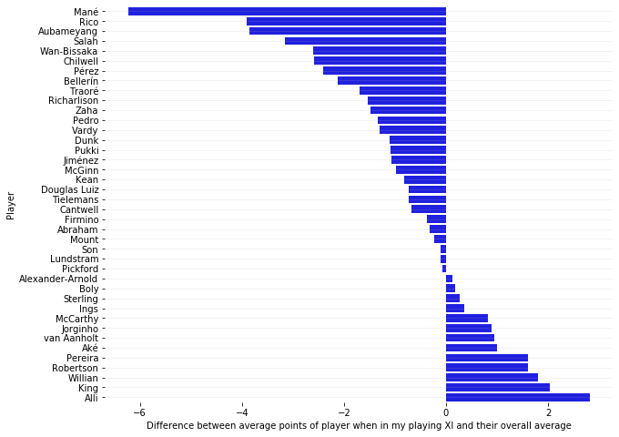

```python
fig=plt.figure(figsize=(10, 8))
sns.barplot(x='diff', y='web_name', data=p1, color='b')
plt.grid(axis = 'y',alpha = 0.2)
plt.ylabel('Player')
plt.xlabel('Difference between average points of player when in my playing XI and their overall average')
sns.despine(left=True, bottom=True);
```

Only 13 players on positive side as compared to 27 on other side, which means I didn't utilize the selected players well.

#### My Points Vs Average Gameweek points

Move to top

First plotting my each gameweek points alongwith overall average points of all users playing FPL in that gameweek:

[figure not shown]

```python
p2 = pd.concat([gameweeks_details[['gw','average_entry_score']],mypoints['points']], axis = 1, join = 'inner').set_index('gw')
p2.plot(title="My GW Points Vs Average GW Points", figsize = (15,8), fontsize=14, marker = 'o')
plt.grid(linestyle='--', alpha = 0.3)
plt.ylim(0,100)
plt.xticks(range(1,len(p2)+2), fontsize = 12)
plt.xlabel('Gameweek', fontsize=14)
plt.ylabel('GW Points', fontsize=14)
plt.text()

if len(mypoints[mypoints['chip'] == '3xc']) == 1:
    plt.axvline(x = (mypoints[mypoints['chip'] == '3xc']['gw'].iloc[0]),
                ymax = (mypoints[mypoints['chip'] == '3xc']['points'].iloc[0])/100,
                c = "green", alpha = 0.5,linestyle = '--')
if len(mypoints[mypoints['chip'] == 'freehit']) == 1:
    plt.axvline(x = (mypoints[mypoints['chip'] == 'freehit']['gw'].iloc[0]),
                ymax = (mypoints[mypoints['chip'] == 'freehit']['points'].iloc[0])/100,
                c = "brown", alpha = 0.5,linestyle = '--')
if len(mypoints[mypoints['chip'] == 'bboost']) == 1:
    plt.axvline(x = (mypoints[mypoints['chip'] == 'bboost']['gw'].iloc[0]),
                ymax = (mypoints[mypoints['chip'] == 'bboost']['points'].iloc[0])/100,
                c = "darkviolet", alpha = 0.5,linestyle = '--')
plt.legend(["Average GW Points","My GW points", "Triple Captain Used", "Freehit Used", "BenchBoost Used"], fontsize=14);
```

Now plotting cumulative points of each gameweek with cumulative overall average points of all users playing FPL in that gameweek:

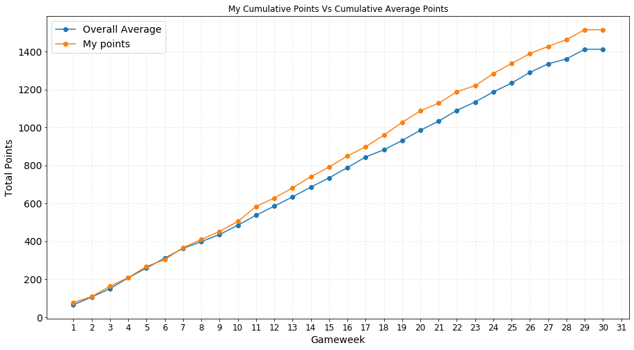

```python
p3 = (pd.concat([gameweeks_details[['gw','average_entry_score']],
                 mypoints['points']],
                axis = 1,
                join = 'inner').set_index('gw')).cumsum()
p3.plot(title="My Cumulative Points Vs Cumulative Average Points", figsize = (15,8), fontsize=14, marker = 'o')
plt.grid(linestyle='--', alpha = 0.3)
plt.xticks(range(1,len(p3)+2), fontsize = 12)
plt.xlabel('Gameweek', fontsize=14)
plt.ylabel('Total Points', fontsize=14)
plt.legend(["Overall Average","My points"], fontsize=14);
```

#### Most Suitable Player to Buy Currently

Move to top

```python
cf.go_offline()

df = players_details[['form','points_per_game','now_cost','team_name','singular_name','first_name','web_name']]
df["now_cost"] = df["now_cost"]/10
df.rename(columns = {'singular_name' : "Player Type"}, inplace = True)
df["name"] = df["first_name"] + ' ' + df["web_name"]
fig = px.scatter(df, x='points_per_game',
                 y='now_cost',
                 size = (players_details["form"].astype(float).values + 0.5)*2,
                 hover_name = "name",
                 hover_data= ["team_name"],
                 color ="Player Type",
                 title = "Most Suitable Player to Buy Currently"
                )
fig['layout']['yaxis'].update({'title': 'Price', 'tickprefix': '£'})
fig['layout']['xaxis'].update({'title': 'Points Per Game'})
fig.update_layout(
    showlegend=True,
    annotations=[
        dict(
            x=1.15,
            y=1.10,
            xref="paper",
            yref="paper",
            showarrow=False,
            text="Bubble Size : Player Form"
        )
    ]
)

fig.show()
```

[interactive chart not shown]